# $\color{#E31A1C}{\text{Belkin}}$ vs. $\color{#6A3D9A}{\text{Elago}}$

Exploratory Data Analysis

Murilo Miranda

2020-February-10

```r
library(sjPlot)
library(forcats)
library(dplyr)
library(ggplot2)
library(RColorBrewer)
```

# Loading data

The data has empty values and the columns are separated by semicolon. **read.csv2** function was used because it has semi-colon as default sep-argument. To solve the problem with empty values, na.strings argument was used with empty value and single space.

```
'data.frame':   15000 obs. of  7 variables:
 $ salary : num  113771 139183 101967 71761 124203 ...
 $ age    : int  59 67 53 26 46 46 34 67 71 43 ...
 $ elevel : int  3 3 2 2 3 2 2 3 2 3 ...
 $ car    : int  14 16 3 8 9 5 19 4 19 20 ...
 $ zipcode: int  6 5 8 5 0 6 8 1 4 1 ...
 $ credit : num  738 679 603 654 627 ...
 $ brand  : Factor w/ 2 levels "Belkin","Elago": 1 2 1 1 NA 2 2 NA 1 NA ...
```

# Preprocessing

## Check data types

In the data-set elevel, car and zipcode are integers. In reality, they are categorical variables, so they are converted into factor. The missing values are converted into ‘No Response’.

## Data conversions

```
     salary age elevel  car zipcode credit       brand
1 113770.67  59   Coll Merc      SE 737.93      Belkin
2 139182.77  67   Coll Niss      NW 679.31       Elago
3 101966.66  53   Prof Volk       W 602.73      Belkin
4  71760.52  26   Prof Hond      NW 653.90      Belkin
5 124202.78  46   Coll Opel       C 627.27 No Response
6  36716.54  46   Prof Chry      SE 461.72       Elago
```

## Check duplicate observations

```
[1] 0
```

## Correlation between variables

```
            salary         age      credit
salary 1.000000000 0.006923108 0.794831141
age    0.006923108 1.000000000 0.004495574
credit 0.794831141 0.004495574 1.000000000
```

### Are missing values at random?

A method I use is a shadow matrix, in which the data-set consists of indicator features where a 0 is given if a value is present, and 1 if it isn’t. Correlating these with each other and the original data can help determine if features tend to be missing together (missing at random - MAR) or not (missing completely at random - MCAR).

I selected the features with numerical values, then their correlations were verified.

```
       No Response
salary  0.08712544
age     0.00154928
credit  0.05358501
```

## Distributions of the variables

### Data Frame Summary

**data**  
**Dimensions:** 15000 x 7  
**Duplicates:** 0

| No | Variable | Stats / Values | Freqs (% of Valid) | Graph | Missing |
| --- | --- | --- | --- | --- | --- |
| 1 | salary [numeric] | Mean (sd) : 87233.6 (37925.2) min < med < max: 19582.9 < 87244 < 161748 IQR (CV) : 65426.1 (0.4) | 14757 distinct values |  | 0 (0%) |
| 2 | age [integer] | Mean (sd) : 49.8 (17.6) min < med < max: 20 < 50 < 80 IQR (CV) : 30 (0.4) | 61 distinct values |  | 0 (0%) |
| 3 | elevel [factor] | 1. Prof 2. Coll 3. HSch 4. Mast | 6584 (43.9%) 5416 (36.1%) 1991 (13.3%) 1009 ( 6.7%) |  | 0 (0%) |
| 4 | car [factor] | 1. Volk 2. Hond 3. Ford 4. Daci 5. BMW 6. Kia 7. Rena 8. Audi 9. Toyo 10. Chry [ 10 others ] | 1293 ( 8.6%) 1121 ( 7.5%) 1082 ( 7.2%) 1076 ( 7.2%) 966 ( 6.4%) 863 ( 5.8%) 757 ( 5.0%) 686 ( 4.6%) 661 ( 4.4%) 658 ( 4.4%) 5837 (38.9%) |  | 0 (0%) |
| 5 | zipcode [factor] | 1. SE 2. W 3. N 4. NW 5. E 6. SW 7. NE 8. C 9. EC | 1709 (11.4%) 1707 (11.4%) 1688 (11.2%) 1681 (11.2%) 1670 (11.1%) 1662 (11.1%) 1642 (10.9%) 1626 (10.8%) 1615 (10.8%) |  | 0 (0%) |
| 6 | credit [numeric] | Mean (sd) : 638.9 (86.7) min < med < max: 423.7 < 638.3 < 849 IQR (CV) : 125.9 (0.1) | 11999 distinct values |  | 0 (0%) |
| 7 | brand [factor] | 1. No Response 2. Belkin 3. Elago | 5000 (33.3%) 4652 (31.0%) 5348 (35.6%) |  | 0 (0%) |

# Remove **No Response** observations in brand variable

## Comparing some variables with and without **No Response**

[output not shown]

## Correlation

```
            salary         age      credit
salary 1.000000000 0.007025207 0.799999892
age    0.007025207 1.000000000 0.002744687
credit 0.799999892 0.002744687 1.000000000
```

## Distributions of the variables

### Data Frame Summary

**dataSet**  
**Dimensions:** 10000 x 7  
**Duplicates:** 0

| No | Variable | Stats / Values | Freqs (% of Valid) | Graph | Missing |
| --- | --- | --- | --- | --- | --- |
| 1 | salary [numeric] | Mean (sd) : 84897.3 (37709.8) min < med < max: 20000 < 84968.9 < 150000 IQR (CV) : 65059 (0.4) | 9757 distinct values |  | 0 (0%) |
| 2 | age [integer] | Mean (sd) : 49.8 (17.6) min < med < max: 20 < 50 < 80 IQR (CV) : 30 (0.4) | 61 distinct values |  | 0 (0%) |
| 3 | elevel [factor] | 1. Prof 2. Coll 3. HSch 4. Mast | 4404 (44.0%) 3497 (35.0%) 1435 (14.3%) 664 ( 6.6%) |  | 0 (0%) |
| 4 | car [factor] | 1. Volk 2. Hond 3. Ford 4. Daci 5. BMW 6. Kia 7. Rena 8. Audi 9. Toyo 10. Chry [ 10 others ] | 846 ( 8.5%) 759 ( 7.6%) 719 ( 7.2%) 740 ( 7.4%) 632 ( 6.3%) 643 ( 6.4%) 555 ( 5.5%) 443 ( 4.4%) 422 ( 4.2%) 446 ( 4.5%) 3795 (38.0%) |  | 0 (0%) |
| 5 | zipcode [factor] | 1. SE 2. W 3. N 4. NW 5. E 6. SW 7. NE 8. C 9. EC | 1167 (11.7%) 1144 (11.4%) 1103 (11.0%) 1113 (11.1%) 1125 (11.2%) 1091 (10.9%) 1094 (10.9%) 1097 (11.0%) 1066 (10.7%) |  | 0 (0%) |
| 6 | credit [numeric] | Mean (sd) : 635.6 (87.3) min < med < max: 423.7 < 635.5 < 849 IQR (CV) : 126.9 (0.1) | 8658 distinct values |  | 0 (0%) |
| 7 | brand [factor] | 1. Belkin 2. Elago | 4652 (46.5%) 5348 (53.5%) |  | 0 (0%) |

# Results

[figure not shown]

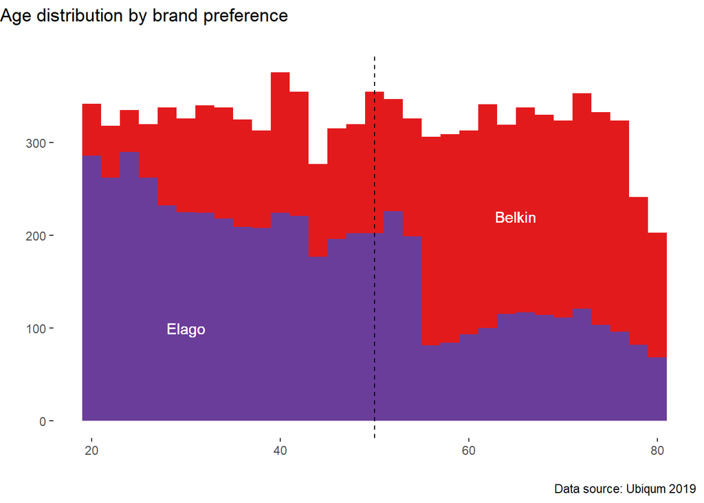

## Model Hypothesis Testing

The null hypothesis ($H_0$): age and educational level don’t affect salary, and the alternative hypothesis ($H_1$): age or educational level do affect the salary amount.

|  | salary |  |  |
| --- | --- | --- | --- |
| Predictors | Estimates | Conf. Int (95%) | P-Value |
| Intercept | 72345.26 | 70676.97 – 74013.55 | **<0.001** |
| Age | 4.75 | -24.93 – 34.44 | 0.754 |
| College Degree | 36160.17 | 34977.33 – 37343.00 | **<0.001** |
| High School Degree | -31503.43 | -33090.80 – -29916.06 | **<0.001** |
| Master’s Degree | 63112.91 | 60938.73 – 65287.09 | **<0.001** |
| Observations | 10000 |  |  |
| R<sup>2</sup> / R<sup>2</sup> adjusted | 0.501 / 0.501 |  |  |

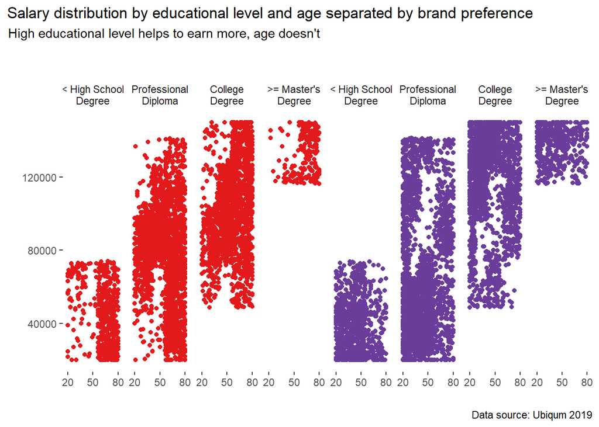

# Conclusion

Age and salary are uniformly distributed and credit is normally distributed. Salary and credit have a high correlation ($\rho$ = 0.795). They are also correlated with educational level, that is, people with a high level of education receive high salary and credit in banks and people with a low level of education receive low salary and credit.

There are more people with **Professional Diploma**, followed by **College Degree**, **High School Degree or lower**, finnally, **Master’s Degree or Higher**. Age at educational level is equally distributed.

Older people and people with intermediate income are associated with the $\color{#E31A1C}{\text{Belkin}}$ brand and younger people and people with low or high income are associated with the $\color{#6A3D9A}{\text{Elago}}$ brand.